# Analysing Housing Conditions in Ames, Iowa

## Data Preprocessing

### Filtering observations

- I filter out all vacant spaces specified by 'NP' (Number of persons) equalling 0.
- I also filter out all save for type of unit of 'housing unit' (TYPE == 1) hence deleting group quarters observations.

```python
housing = new_york[(new_york["TYPE"] == 1) & ~(new_york["NP"] == 0)] # ~ symbol for "not"
print(housing.shape)
print(housing.info()) # dTypes and Non-Null
print(housing.describe()) # 5-number summary
print(housing.isna().sum()) #total number of N/A entries per column
```

```
(74183, 40)
<class 'pandas.core.frame.DataFrame'>
Int64Index: 74183 entries, 0 to 92083
Data columns (total 40 columns):
 #   Column    Non-Null Count  Dtype
---  ------    --------------  -----
 0   NP        74183 non-null  int64
 1   TYPE      74183 non-null  int64
 2   ACCESS    74183 non-null  float64
 3   ACR       44024 non-null  float64
 4   BATH      74183 non-null  float64
 5   BDSP      74183 non-null  float64
 6   BROADBND  56989 non-null  float64
 7   COMPOTHX  74183 non-null  float64
 8   ELEP      74183 non-null  float64
 9   GASP      74183 non-null  float64
 10  HFL       74183 non-null  float64
 11  INSP      46735 non-null  float64
 12  RMSP      74183 non-null  float64
 13  RNTP      26287 non-null  float64
 14  RWAT      74183 non-null  float64
 15  RWATPR    74183 non-null  float64
 16  STOV      74183 non-null  float64
 17  TEN       74183 non-null  float64
 18  TOIL      74183 non-null  float64
 19  VACS      0 non-null      float64
 20  VALP      46735 non-null  float64
 21  VEH       74183 non-null  float64
 22  WATP      74183 non-null  float64
 23  FES       48387 non-null  float64
 24  FINCP     48676 non-null  float64
 25  GRNTP     26287 non-null  float64
 26  HHL       74183 non-null  float64
 27  HHT       74183 non-null  float64
 28  HINCP     74183 non-null  float64
 29  KIT       74183 non-null  float64
 30  NRC       74183 non-null  float64
 31  PLM       74183 non-null  float64
 32  R60       74183 non-null  float64
 33  R65       74183 non-null  float64
```

[output cut: 46 more lines]

```
HHL             0
HHT             0
HINCP           0
KIT             0
NRC             0
PLM             0
R60             0
R65             0
SMOCP       27448
TAXP        27448
WIF         25507
WKEXREL     25507
WORKSTAT    25796
FYBLP           0
dtype: int64
```

### Aggregation

- I create a new 'gross_utility' column with electricity, water, and gas costs summed together.

It must be noted, this is an assumption as spending habits may vary among households and actual spending habits may not reflect a monthly saving for utility costs.

```python
housing["gross_utility"] = (housing["ELEP"] + housing["GASP"] + housing["WATP"])
housing["gross_utility"]
```

[output not shown]

```python
housing["aged_persons"] = (housing["R60"] + housing["R60"])/2
housing["aged_persons"].map(lambda x : 1 if not x == 0 else 0)
housing["aged_persons"].sample(5)
```

```
43510    0.0
65374    0.0
22038    0.0
51517    1.0
81189    1.0
Name: aged_persons, dtype: float64
```

## Visualizing Important variables and relationhips

- There are two metrics of cost and value of housing that I wish to explore:
  - GRNTP - Gross rent per month
  - VALP - Value property
- A simple scatter plot shows the two variables are mutually exclusive. Documentation details 'GRNTP' as rent paid for rented houses while 'VALP' is solely for bought or morgaged houses.

[figure not shown]

```python
housing.plot.scatter(x="GRNTP", y="VALP")
plt.title("Gross Rent of House vs Value of Property")
plt.xlabel("Gross Rent Paid Per Month (dollars)")
plt.ylabel("Value of Property (dollars)")
plt.show()
```

- Firstly, since I will be repeating many lines of code plotting histograms and using describe() method of Pandas, I thought I would make a helper function to make it easier.

```python
# Helper function.
#
def plot_hist_describe(x, title="no title", xlabel = "no x label", ylabel = "no y label", bins = 10):
  print(x.describe()) if isinstance(x, (pd.DataFrame, pd.Series)) else 0
  plt.hist(x, bins = bins)
  plt.title(title)
  plt.xlabel(xlabel)
  plt.ylabel(ylabel)
  plt.show()
```

```
count    4.673500e+04
mean     3.593957e+05
std      5.354001e+05
min      1.000000e+02
25%      1.100000e+05
50%      2.350000e+05
75%      4.300000e+05
max      4.775000e+06
Name: VALP, dtype: float64
```

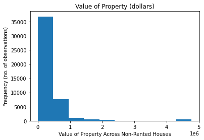

```python
#exploring property value
plot_hist_describe(housing["VALP"], "Value of Property (dollars)", "Value of Property Across Non-Rented Houses", "Frequency (no. of observations)")
```

- It is clear the data is very positively skewed. I will attempt applying a boxcox transformation [docs](https://docs.scipy.org/doc/scipy/reference/generated/scipy.stats.boxcox.html) to make data seeem normal.

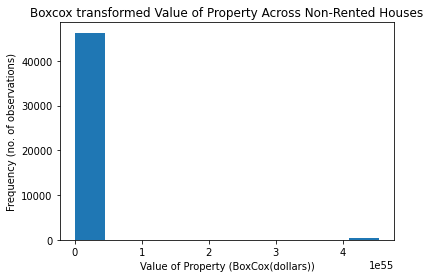

```python
housing_value_boxcox, _= stats.boxcox(housing["VALP"])
plot_hist_describe(housing_value_boxcox, "Boxcox transformed Value of Property Across Non-Rented Houses", "Value of Property (BoxCox(dollars))", "Frequency (no. of observations)" )
```

- Since boxcox transformation didn't work so well, I will attempt a standard squareroot transformation which yields better results although it is still skewed, more data can be seen.

```
count    46735.000000
mean       523.366469
std        292.378231
min         10.000000
25%        331.662479
50%        484.767986
75%        655.743852
max       2185.177338
Name: VALP, dtype: float64
```

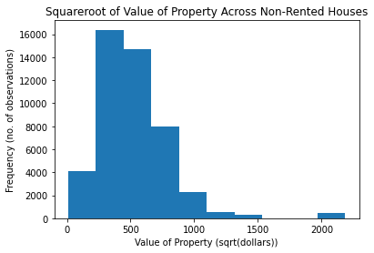

```python
housing_value_sqrt = np.sqrt(housing["VALP"])
plot_hist_describe(housing_value_sqrt, "Squareroot of Value of Property Across Non-Rented Houses", "Value of Property (sqrt(dollars))", "Frequency (no. of observations)")
```

```python
housing_value_sqrt[housing_value_sqrt>3].size/housing_value_sqrt.size
anomaly = housing[housing["VALP"]>2.4e+06]["VALP"]
anomaly.size == anomaly[anomaly == 4775000].size #use size property since it is a series
```

```
True
```

- For sake of consistency and to prevent heavy skewing, I have decided to take out these 466 observations. Given that there are 74183 total observations, 99% of the data will remain.

```python
housing = housing[(housing["VALP"]<4775000) | housing["VALP"].isna()] #account for na since otherwise it will delete rows of houses that are rented
print(housing["VALP"].describe())
housing_value_sqrt = np.sqrt(housing["VALP"])
```

[output not shown]

Plotting to see less skew

```
count    46269.000000
mean       506.629478
std        241.353612
min         10.000000
25%        324.037035
50%        479.583152
75%        648.074070
max       1549.193338
Name: VALP, dtype: float64
```

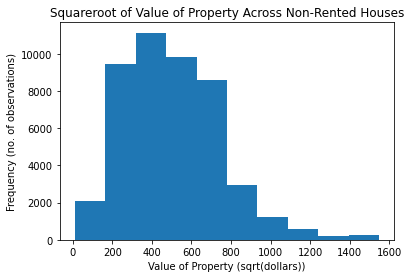

```
initial skew 2.3762986402120045 final skew 0.740701219187067
```

```python
plot_hist_describe(housing_value_sqrt, "Squareroot of Value of Property Across Non-Rented Houses", "Value of Property (sqrt(dollars))", "Frequency (no. of observations)")
print("initial skew", housing["VALP"].skew(), "final skew",housing_value_sqrt.skew()) #normal distribution would have 0 skew
```

- I now explore the other metric of cost which is "GRNTP" Gross monthly rent

```
count    26287.000000
mean      1189.767376
std        698.241365
min          4.000000
25%        709.000000
50%       1070.000000
75%       1500.000000
max       4380.000000
Name: GRNTP, dtype: float64
```

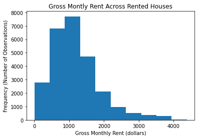

```
Original skew 1.282810171036858
```

```python
gross_rent = housing["GRNTP"]
plot_hist_describe(gross_rent, "Gross Montly Rent Across Rented Houses", "Gross Monthly Rent (dollars)", "Frequency (Number of Observations)" )
print("Original skew", housing['GRNTP'].skew())
```

- Gross rent is also positively skewed. In order to make the data more normal as well as match the units of squareroot(dollars) of Value of Property, I apply a square root transformation to 'GRNTP' column. This makes the data seem normal.

```
count    26287.000000
mean        33.070005
std          9.805398
min          2.000000
25%         26.627047
50%         32.710854
75%         38.729833
max         66.181568
Name: GRNTP, dtype: float64
```

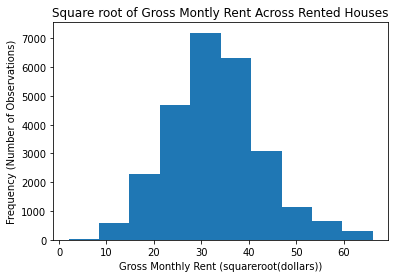

```
Final skew 0.3664983680908521
```

```python
gross_rent_sqrt = np.sqrt(gross_rent)
plot_hist_describe(gross_rent_sqrt,"Square root of Gross Montly Rent Across Rented Houses","Gross Monthly Rent (squareroot(dollars))", "Frequency (Number of Observations)")
print("Final skew", gross_rent_sqrt.skew())
```

- The other variable related to cost that might be worthwhile finding relationships with is 'SMOCP' (Selected Monthly Owner Costs). This includes costs related to: the sum of payments for mortgages, deeds of trust, contracts to purchase, or similar debts on the property. From the documentation, this is cost is only associated with non-renting houses such as morgaged or fully-owned properties.

[output not shown]

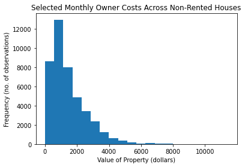

```python
plot_hist_describe(housing["SMOCP"],"Selected Monthly Owner Costs Across Non-Rented Houses", "Value of Property (dollars)",  "Frequency (no. of observations)", bins=20)
```

- Since this data is also heaviily positively skewed, I will apply a square root transformation. This will also make the units the same as the other cost variables : squareroot(dollars).

```
count    46269.000000
mean        37.031479
std         14.748019
min          0.000000
25%         26.153394
50%         34.669872
75%         46.508064
max        106.864400
Name: SMOCP, dtype: float64
count    46269.000000
mean        37.031479
std         14.748019
min          0.000000
25%         26.153394
50%         34.669872
75%         46.508064
max        106.864400
Name: SMOCP, dtype: float64
```

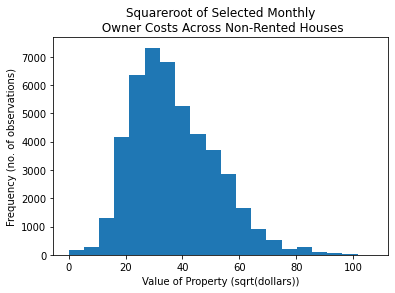

```
initial skew 1.8242263751687389 final skew 0.685788080256808
```

```python
selected_monthly_sqrt = np.sqrt(housing["SMOCP"])
plot_hist_describe(selected_monthly_sqrt,"Squareroot of Selected Monthly\n Owner Costs Across Non-Rented Houses","Value of Property (sqrt(dollars))", "Frequency (no. of observations)", bins=20  )
print("initial skew", housing["SMOCP"].skew(), "final skew",selected_monthly_sqrt.skew()) #normal distribution would have 0 skew
```

The last variable related to cost that I consider worthwhile including is annual gross utility bill.

[output not shown]

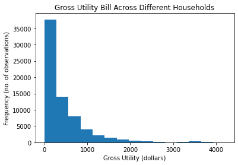

```python
plot_hist_describe(housing["gross_utility"],"Gross Utility Bill Across Different Households", "Gross Utility (dollars)",  "Frequency (no. of observations)", bins=15)
```

- For the same reasons as the previous variables, I apply a squareroot transformation

[output not shown]

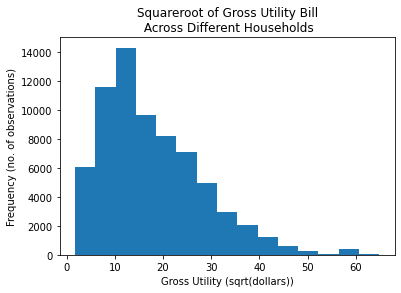

```
initial skew 2.6806339595952777 final skew 0.9564798783227326
```

```python
gross_utility_sqrt = np.sqrt(housing["gross_utility"])
plot_hist_describe(gross_utility_sqrt,"Squareroot of Gross Utility Bill\n Across Different Households","Gross Utility (sqrt(dollars))", "Frequency (no. of observations)", bins=15 )
print("initial skew", housing["gross_utility"].skew(), "final skew",gross_utility_sqrt.skew()) #normal distribution would have 0 skew
```

### Exploring socio-economic variables

- The main variables from my prior knowledge that I wish to explore are Household Income (HINCP), Household Family Type (HHT), Workexperience of householder (WKEXREL), family type (FES) and number of persons over 15 who live in household (NP).
- Here I visualize 'HINCP' (Annual Household Income)

```
count    7.371700e+04
mean     8.419478e+04
std      9.782762e+04
min     -9.000000e+03
25%      2.800000e+04
50%      5.904000e+04
75%      1.054000e+05
max      2.090000e+06
Name: HINCP, dtype: float64
```

[figure not shown]

```python
household_income = housing["HINCP"]
plot_hist_describe(household_income, "Annual Household Income across different households", "Household Income (dollars)", "Frequency (No. of Observations)", bins=100)
```

- One can see that the data is heavily skewed by very rich households that live in New York. In order to ammend this, I will drop values that are higher than 1.5 times the interquartile range of the data. Although this is useful information that is lost, I think it will be worthwhile since these extreve values are exceptions and will not negatively impact on any corellation.
- Furthermore, it is important to note that according to documentation, negative values correspond to households that are in debt.

```
count     69554.000000
mean      66381.562915
std       49698.512432
min       -9000.000000
25%       26500.000000
50%       55000.000000
75%       95600.000000
max      221460.000000
Name: HINCP, dtype: float64
```

[figure not shown]

```python
q1, q3 = np.percentile(housing["HINCP"], [25, 75])
iqr = q3-q1
cutoff = q3 + (1.5 * iqr)
#filter data
housing = housing[housing["HINCP"]<cutoff]
#plotting HINCP column again
household_income = housing["HINCP"]
plot_hist_describe(household_income, "Annual Household Income across different households", "Household Income (dollars)", "Frequency (No. of Observations)", bins=20)
```

- This will also impact all the other variables and their distribution since some datapoints will not be included
- This has also greatly improved the skew of the data across all variables
- Since this has impacted previous variables, I rerun variable assignments that depended on the old version of the housing dataset

```python
housing_value_sqrt = np.sqrt(housing["VALP"])
gross_rent_sqrt = np.sqrt(housing["GRNTP"])
selected_monthly_sqrt = np.sqrt(housing["SMOCP"])
```

- To visualize the remaining chosen variable, work experience of householder and family type (WKEXREL), I use a bar plot with count/frequency on the y-axis and the different categories on the x-axis sorted in decreasing frequency. The categorical numbers correspond as follows:
1. Householder and spouse worked FT
2. Householder worked FT; spouse worked < FT
3. Householder worked FT; spouse did not work
4. Householder worked < FT; spouse worked FT
5. Householder worked < FT; spouse worked < FT
6. Householder worked < FT; spouse did not work
7. Householder did not work; spouse worked FT
8. Householder did not work; spouse worked < FT
9. Householder did not work; spouse did not work
10. Male householder worked FT; no spouse present
11. Male householder worked < FT; no spouse present
12. Male householder did not work; no spouse present
13. Female householder worked FT; no spouse present
14. Female householder worked < FT; no spouse present
15. Female householder did not work; no spouse present
- 'FT' means fulltime

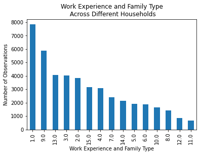

```python
work_experience = housing["WKEXREL"].value_counts()
work_experience.describe()
work_experience.plot.bar()
plt.title("Work Experience and Family Type\n Across Different Households")
plt.xlabel("Work Experience and Family Type")
plt.ylabel("Number of Observations")
plt.show()
```

- We can observe that the most common households are those that have spouses who both work full time

## Exploring Corellations and Statistical Differences

- The first corellation I explore is if one esxists between Annual Household Income and all the housing expense variables: Value of Property (VALP), gross rent paid per month (GRNTP) and lastly selected monthly ownership costs (SMOCP).

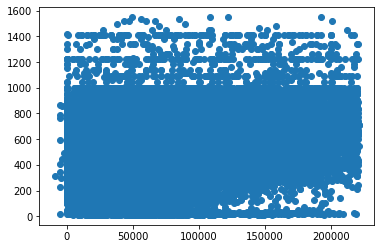

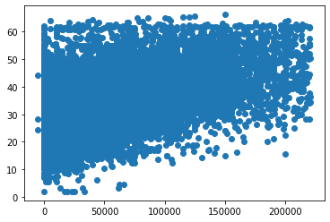

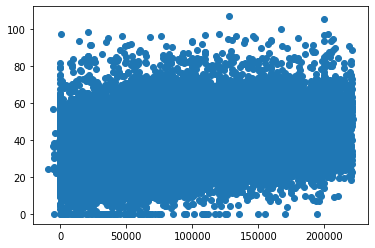

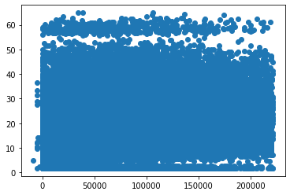

```python
#preliminary scatterplots
plt.scatter(x=housing["HINCP"], y=housing_value_sqrt)
plt.show()
plt.scatter(x=housing["HINCP"], y=gross_rent_sqrt)
plt.show()
plt.scatter(x=housing["HINCP"], y=selected_monthly_sqrt)
plt.show()
plt.scatter(x=housing["HINCP"], y=gross_utility_sqrt)
```

- From a preliminary standpoint, although none of them have a clear corellation, annual income and squareroot of gross rent seems to have a kind of positive corellation, followed by annual income and squareroot of selected monthly ownership costs.
- Annual income and squareroot of property value, and annual income and annual gross utility do not seem to have any corellation which I did not expect.
- Even though I do indeed get a corellation coeffecient, I get a really weird p-value of 0.0 when I run a pearson corellation coefficient. According to [this](https://stackoverflow.com/questions/20530138/scipy-p-value-returns-0-0), this might indicate that the value is smaller than what a float64 is able to represent.
- In order to prove that this is the case, I will rerun the statistical test with a smaller sample of the same variables (instead of 42793 samples) which should return a p-value greater than 0.0 but still corellated, ie. < 0.05

```python
stats.pearsonr(housing[~(housing["VALP"].isna())]["HINCP"], housing_value_sqrt.dropna())
```

```
(0.30801448844235746, 0.0)
```

```python
stats.pearsonr(housing[~(housing["VALP"].isna())]["HINCP"][:5000], housing_value_sqrt.dropna()[:5000])
```

```
(0.31167781959646823, 4.464159033728769e-113)
```

I proceed to check for a linear relationship between annual income and the squareroot of selected monthly ownership costs

```python
stats.pearsonr(housing[~(housing["SMOCP"].isna())]["HINCP"], selected_monthly_sqrt.dropna())
```

```
(0.42510021019241273, 0.0)
```

- Since p-value is 0, as before I will confirm if this is just a really small value by confirming on a smaller sample

```python
stats.pearsonr(housing[~(housing["SMOCP"].isna())]["HINCP"][:5000], selected_monthly_sqrt.dropna()[:5000])
```

```
(0.4388377815993059, 1.7922311796646798e-234)
```

- We can reject the null hypothesis that the two variables are not corellated since p-value < 0.05
- There is thus a positive linear corellation between annual houshold income and the squareroot of selected monthly ownership costs
- The Pearson's Corellation Coeffecient of 0.4389 indicates that there is a stronger positive corellation between annual income and squareroot of selected monthly ownership costs than annual income and squareroot of value of property

```python
stats.pearsonr(housing[~(housing["GRNTP"].isna())]["HINCP"], gross_rent_sqrt.dropna())
```

```
(0.5053602929136876, 0.0)
```

- We can reject the null hypothesis that the two variables are not corellated since p-value < 0.05
- There is thus a positive linear corellation between annual houshold income and the squareroot of gross monthly income
- This result is just as to be expected as it matches the scatterplot visualisation and the comment I made earlier about which graphs indicates a greater positive corellation.
- A Pearson corellation coeffecient of 0.5 indicates quite strong corellation between annual household income and squareroot of gross monthly income